# Practical 1: Getting Started

## How do I Know it Worked?

With the virtual machine running, you will *mainly* interact with Python through your browser. To check if it’s running, we just have to visit the web page and see what happens: http://localhost:8888/lab/tree/work/. We’ll talk more about exactly what is going on over the next few weeks, but this should show you a page that looks something like this (probably with fewer files listed on the left-hand side):

[figure not shown]

Screenshot of Jupyter Lab

**NoteSee the Container Run (and Run)…**

Once you have started a container, the machine **will continue running** until you either restart the computer or stop the container. This *can* consume memory and battery power indefinitely.

# Setting Up GitHub

Understanding how to use Git and GitHub effectively is a core element of learning to code. So one of the *first* things that we are going to do is set you up with an account and a new repository.

## Your New GitHub Account

It doesn’t really matter which way you do this, but we recommend that you set up your new GitHub account with *both* your personal and your UCL email addresses. GitHub ‘knows’ about educational users and will give you access to more features for free if you associate a `.ac.uk` email address to your account. So choose one email address to start with and then add the other one later.

From a security standpoint you should *also* enable 2-factor authentication so that you receive a text message when you log in on a new machine and are asked to confirm a code.

So in order to complete this task you need to do the following (**more detailed explanations below**):

1. Create a login with [GitHub](https://github.com) (if you’ve not done so already).
2. Create a new **private** repository on GitHub (see below).
3. Edit the `README.md` and `.gitignore` files for your new repository (see below).
4. Save the changes (this is called a ‘commit’) and explain in a general way what edits you did (see below).
5. Work out how to compare the original and edited versions of any file in your browser.

## Creating a Private Repository

To create a repository, click on the `+` at the upper-right corner of the GitHub web page and select `New Repository`. You might as well call your ‘repo’ `fsds` or `foundations` since that’s a lot shorter than `foundations_of_spatial_data_science`.

**ImportantYour ‘Repo’ Name**

For the purposes of this tutorial (and all subsequent tutorials) I will assume that your repository is called `fsds`. You can call it whatever you like, in which case you will *always* need to substitute the name that *you* chose wherever you see me write `fsds`.

Click `Create Repository` and you should end up on a page that looks like this:

[figure not shown]

Repository created

Your new repository has been created (on GitHub)! The `README` is a file – written in Markdown – that explains the purpose of a repository and any other notes you care to add.

# Updating the .gitignore File

The `.gitignore` file tells Git what files to ignore by default. Unless you *force* Git to add an ignored file it will happily coexist in your *local* repository alongside files that are version-controlled and ‘shared’ with GitHub. Why would you want this? Because data does *not* belong in Git: large files especially will totally screw up your repository and they are really hard to remove. So we want to tell Git that it should leave those alone.

The Python template for `.gitignore` includes a lot of useful files and folders that we wouldn’t want Git to track for us. But it *doesn’t* include data. In your web browser, click on the `.gitignore` file and then the ‘pencil’ icon on the right to edit it on GitHub. You should see something like this:

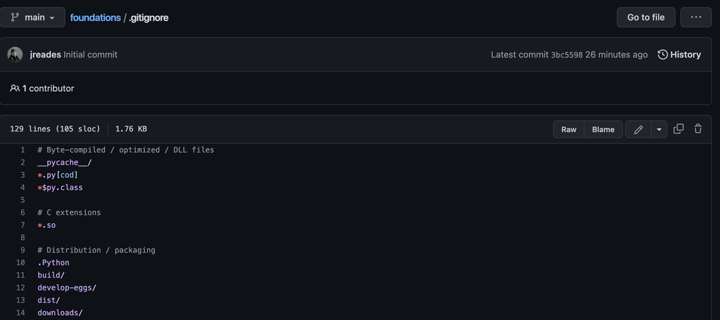

Editing the .gitignore file

## Exclude Data Files

We want to make it hard to accidentally add a large data file to our repository. Git/GitHub isn’t designed for large, binary files (you can’t ‘read’ a Parquet file) and we assume that data is backed up or available elsewhere, but our *code* is not! So as a first step we want to exclude files that are likely to just be ‘data’:

| File Type | Extension |
| --- | --- |
| CSV | `.csv` |
| Excel | `.xls`, `.xlsx` |
| Zip | `.zip` |
| GZip | `.gzip` |
| Parquet | `.parquet`, `.geoparquet` |

Maybe look to see how files are already done to help you figure out how to exlcude `.zip`, `.gz`, and `.csv` files… but as a hint: `*` means ‘any sequence of characters’ so `*.py` means any Python script file ending in `.py`.

## Exclude a Data Directory

To make it even *less* like that we accidentally include data, let’s also exclude a `data` directory from our repository. As a clue, nearly everything in the `Distribution / packaging` section of the `.gitignore` file is a directory to be excluded from Git.

So how would you indicate that `data` is a directory? Once you’re sure, add the `data` directory!

When you are done, don’t forget to add a ‘commit message’ (e.g. ‘Added file types to exclude to .gitignore’) at the bottom and then click `Commit changes`.

**TipQuick Answer**

I don’t want you to get hung up on this *one* thing in Practical 1, so if you just can’t make sense of what you’re being asked to do here, have a look at the Answers at the bottom of this page.

## Check Your Changes

Once you have committed your changes, you should be back to the default view of the `.gitignore` file but there should be a message to the effect of `Latest commit <some hexadecimal number> 10 seconds ago` and, next to that, a `History` button.

Click on ‘History’ and let’s go back in time!

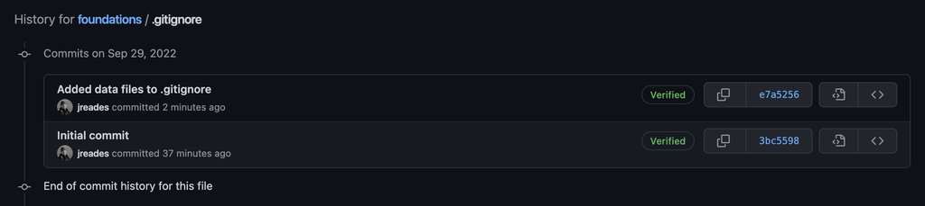

The Gitignore history

On the history page you can browse every edit to your file. Whenever you `commit` a file, this like taking a snapshot at a point in time. Using the ‘History’ you can compare two different snapshots in order to see what has changed. This would help you to work out how you broke something, check that requested changes have been made, or see how an error might have been introduced.

**TipViewing Your Commit History**

You can mouseover the buttons to see what they do. Why don’t you try to find `See commmit details` and check what edits you made to the `.gitignore` file? You should see at least *three* plusses in the history view representing three new lines in the `.gitignore` file.

# Creating Your First Remote File

To get some practice with Markdown let’s write up some notes direclty into our GitHub repository (aka ‘repo’). You’ll notice that we’ve not yet hit the *BIG GREEN BUTTON* marked `Add a README`… Let’s do that now!

This will take you to an editing page for the new `README.md` file. You can type directly into this web page and it will update the repository, but *only* once you `commit` your edits.

## Working on Your Markdown

Write your `README` file using *at least* the following Markdown features:

- A level-1 header (`#`)
- A level-3 header (`###`)
- Italic text (`_this is italicised_`)
- Bold text (`**this is bold**`)
- A link (`[link text](url)`)
- An image (`![Alt text](image_location)`)

If you’re unsure how these work, just double-click on *this text* and you’ll see Markdown in a Jupyter notebook. Here’s some sample text to get you started:

```markdown
### Foundations of Spatial Data Science

This repository contains practicals and notes from the _Foundations_ module.

You can find the original [here](https://jreades.github.io/fsds/).
```

**Don’t forget to check out the “Preview” tab!**

## Commititing a Change

Once you’re happy with how your text looks and works, it’s time to commit! Scroll down to where you see something like this (you will see your *own* GitHub username, not mine):

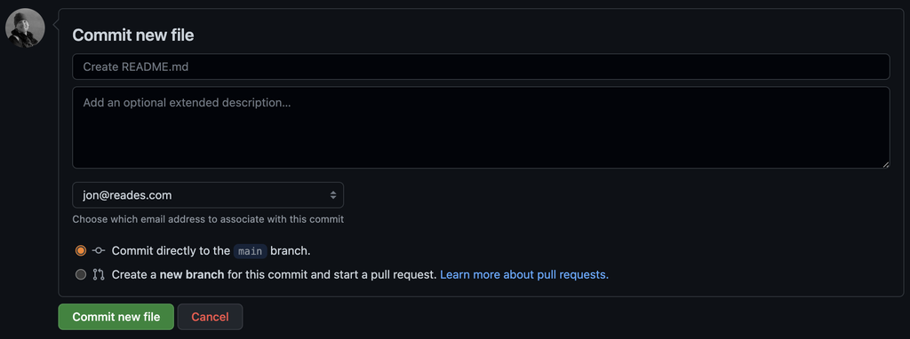

GitHub Commit

You can just accept the description (*e.g.* `Create README.md`) or you can write your own. You can also provide an extended description if you choose. Then click `Commit new file` and you will see your new README appear.

# Setting Up Git Locally

OK, so now we have our Git repository set up remotely and want to create a local *clone* so that we can easily syncrhonise changes between GitHub and our computer. Free backups and collaboration!

## Configuring Defaults

The first thing to do is set up the default username and email for GitHub. These can be changed on a project-by-project basis, but to begin with it’s best to set up the *global defaults*. Using the Terminal, enter the following (replacing `<...>` with *your* details):

```bash
git config --global user.email '<your GitHub email address>'
git config --global user.name '<your GibHub username>'
```

**TipRecall: Convention!**

As a reminder, `<...>` is a convention in programming to indicate that you should replace the text between the `<` and `>` with something that makes sense in your context. For example, if you see `'<your GitHub email address>'` you should type, for *example*, `'j.reades@ucl.ac.uk'`. You do *not* include the `<` or `>` characters!

## Creating a Personal Access Token

For copying changes up to/down from GitHub, you *must* use a Personal Access Token. This is like issuing special passwords that allow only limited access to parts of your GitHub account.

To create a Personal Access Token:

- Visit *your* GitHub User Page (e.g. github.com/jreades)
- Click on *your* user icon (at the top-right corner of the page) and click the `Settings` link (near the bottom on the right side of the page).
- Scroll down the [settings page](https://github.com/settings/profile) until you get to `Developer settings` (near the bottom on the *left* side of the page).
- Click the `Developer settings` link to reach [the ‘apps’ page](https://github.com/settings/apps) and then click on the `Personal access tokens` link.
- Select `Tokens (classic)` from the left-hand menu and then click the `Generate new token` button.

**TipTypes of Personal Tokens**

You now need to choose the type of token to generate. I *personally* find the old type of tokens easier to work with because the ‘new’ fine-grained tokens are intended to support complex workflows when all we’re trying to do is allow one computer to push/pull from Git.

- `Generate new token (classic)` for general use token and then specify the following:
  - I’d suggest writing `FSDS Token` or something similar in the `Note` section.
  - Set the expiration to `90 days`
  - Click the `repo` tickbox for ‘Full control of private repositories’.
- Save the resulting token somewhere safe as you will need it again! (e.g. a Note on your phone, a password manager, etc.).

**WarningKeep your Personal Token Safe**

You will need it at least twice in this tutorial and may want to use it again on other computers. You can always create a new one, but then you’ll need to update every computer where you access your GitHub repositories.

## Cloning Your Repository

Now we are going to `clone` (i.e. copy) the repository that you just created on to your own computer. This is surprisingly straightforward provided that you have installed the command line tools.

On your private repository page, click on the green button labeled `Code` visible in the screenshot below:

[figure not shown]

Screenshot of cloning interface

You should then copy your **HTTPS URL**.

Now go back to the Terminal or PowerShell that you left open earlier and type the following (replacing `<the_url_that_you_copied_from_the_browser>` with the URL that you copied from GitHub):

```bash
git clone <the_url_that_you_copied_from_the_browser>
```

The first time that you do this, you will need to provide login information. Use your GitHub username and the Personal Access Token that you just created. On your computer you should now see a new directory with the same name as your repository. For example: `$HOME/Documents/CASA/fsds`.

## Storing Credentials & ‘Pulling’

You can now activate the credtial helper that will store your Personal Access Token (though you should *still* keep your secure note!):

```bash
cd fsds
git config credential.helper store
git pull
```

When you type `git pull` you *should* be asked *again* for your username and password. You should (again) use the Personal Access Token as your password. You should not be asked again for pushing or pulling data into this GitHub repository. If you are *not* asked for your Personal Access Token then this likely means that your token is already saved and ready to use on all future ‘actions’.

## Jupyter < - > Your Computer

If you now go back to Jupyter, you should now see that the `work` directory is actually the same as the `CASA` directory that you created earlier; you know this because you can now see an `fsds` directory that wasn’t there before.

This is because Podman is ‘mounting’ the `work` directory in the container to the `CASA` directory on your computer. This means that you can save files in the `work` directory in Jupyter and they will be saved in the `CASA` directory on your computer.

**NoteOrganising Your Work**

There are any number of ways to organise your CASA work, what’s important is that you are *logical* about things like names and hierarchy. This will make it much easier to access files and notebooks using Podman, Quarto, *and* Python.

## Adding a Local File to Your Repository

In order to tie together the different concepts covered above, we are now going add Practical 1 (*this* practical) to *your* GitHub repo. The easiest way to do this is to download the notebook by clicking on the `Jupyter` link on the right side of this page. So the process is:

1. Click on the Jupyter link to save this file to your computer as a notebook with the extension `.ipynb`.
2. Move the file to your new repository folder (*e.g.* `$HOME/work/Documents/CASA/fsds/`).

**TipFile Extensions**

It is *highly* likely that your browser automatically added a `.txt` extension when you saved the Notebook file to your computer. You need to remove that ending to your file name or Jupyter won’t be able to run it. You can rename a file by either doing it directly in the Finder/Windows Explorer, or by *moving* (`mv`) the file:

```bash
mv <notebook_name>.ipynb.txt <notebook_name>.ipynb
```

In the Terminal/PowerShell we now need `add` this file to Git so that it knows to keep track of it. Unlike Dropbox or OneDrive, just putting a file in a repo directory does *not* mean that Git will pay attention to it:

```bash
# Assuming that you are 'in' the 'fsds' directory...
git add Practical-01-Getting_Started.ipynb
git commit -m "Adding notebook 1 to repo."
```

**WarningAdd, Commit, Push, Repeat**

Unless you have *added* and *committed* a file to Git then it is *not* version controlled.

Unless you have *pushed* your committed files to GitHub they are only backed up locally.

## Status Check

We now want to check that the file has been successfully added to Git. We do this with a `status` check in the repository directory (*i.e.* `cd $HOME/work/Documents/CASA/fsds/`):

```bash
git status
```

You should see something like:

```bash
On branch main
Your branch is ahead of 'origin/main' by 1 commit.
  (use "git push" to publish your local commits)
```

This is telling you that your local computer is 1 commit (the one that you *just* completed) ahead of the ‘origin’, which is on GitHub. GitHub doesn’t *have* to be the origin (nor does the repository have to be one that we created in order to be an origin) but *conceptually* and *practically* it’s easier to create new repositories on GitHub and clone them to our computer.

## Keep Pushing

To synchronise the changes we just made, let’s follow Git’s advice:

```bash
git push
```

You should see *something* like the below series of messages (the exact details will differ, but the ‘Enumerating, Counting, etc’ messages will be the same):

```bash
Enumerating objects: 5, done.
Counting objects: 100% (5/5), done.
Delta compression using up to 8 threads
Compressing objects: 100% (3/3), done.
Writing objects: 100% (3/3), 306 bytes | 306.00 KiB/s, done.
Total 3 (delta 2), reused 0 (delta 0), pack-reused 0
remote: Resolving deltas: 100% (2/2), completed with 2 local objects.
remote: This repository moved. Please use the new location:
remote:   https://github.com/jreades/fsds.git
To https://github.com/jreades/fsds.git
   7410d0e..45aa80a  main -> main
```

If you now go over to your browser and visit your GitHub repo page (*e.g.* `https://jreades.github.io/fsds/`) — pressing the `Reload` button if you had the page open already — then you should see that the file you added *on your computer* is also showing up on the GitHub site as well! This means it’s now fully version-controlled and backed-up.

**WarningKeep Pushing**

Unless have *pushed* your commits to GitHub they are *only* stored on *your* computer. So your files can be properly version-controlled, but without a *push* if you lose your computer you *still* lose everything!

## More About Git

From here on out you can keep changes made either directly on GitHub or locally on your computer (or any *other* computer to which you `clone` your repository) in synch by using `git push` (to *push* changes from a local computer *up* to the origin on GitHub) and `git pull` (to *pull* changes available on the origin *down* to the local computer).

That said, you can do a *lot* more than just push/pull to your own repository and [this Twitter thread](https://twitter.com/ChrisStaud/status/1574277175527735296) leads to a lot of useful additional resources to do with Git:

- [Introduction to Version Control with Git](https://programminghistorian.org/en/lessons/retired/getting-started-with-github-desktop) on the Programming Historian web site is written for digital humanities researchers so it’s intended to be accessible.
- [Oh My Git](https://ohmygit.org/) is an ‘open source game’ to help you learn Git.
- [Git Meets Minesweeper?](https://profy.dev/project/github-minesweeper) is apparently a ‘thing’.
- [Visual Git Reference](http://marklodato.github.io/visual-git-guide/index-en.html) if you think visually or just want to check your understanding.
- [Version Control with Git](https://swcarpentry.github.io/git-novice/) is a Software Carpentries lesson that takes you quickly through the important elements of getting set up and started. It would be a good refresher.
- [Altassian’s Documentation](https://www.atlassian.com/git/tutorials) provides more detailed explanations of the commands and options.
- [Learn Git Branching](https://learngitbranching.js.org) focusses on a key concept for software *collaboration*.
- [Git Immersion](https://gitimmersion.com) provides a ‘guided tour’ of the fundamentals.

**Tip**

For the [Group Work](https://jreades.github.io/fsds/assessments/group.html) every member of your group will need to make contributions to a GitHub repository. This will require learning how to invite others to be contributors, how to merge changes, and how to deal with conflicts of the coding kind.

# Setting up a GitHub Web Site

**TipBonus Content**

It is not core to this module, but if you’d like to really make the most of Git, why not create a GitHub.io web site? Using Markdown (for the most bare bones effect) or code (via Quarto), you can render and push a web site to `<your GitHub username>.github.io/`. You might find this useful for creating a simple portfolio, blog, or other collection of ‘outputs’ that you can use to demonstrate to employers that you know your way around.

Rather than create a GitHub.io site using your *Foundations* repository, we’d recommend building one in the separate ‘main’ repository so that, for example, jreades.github.io, returns a web page.

To do this, the steps are [detailed here](https://docs.github.com/en/pages/getting-started-with-github-pages/creating-a-github-pages-site#creating-a-repository-for-your-site), but read on to get an overview:

1. On the GitHub web site, create a new repository called `<your username>.github.io` (where `<your username>` is whatever your github username is). So for us, it would mean creating a *new* repository called `jreades.github.io`.
2. For your first web site, try setting up GitHub pages **without** specifying a branch: this way, *anything* that you put into your GitHub repository will show up on the public web site. Later, when you are more comfortable with GitHub, you may wish to switch to using a branch so that you can do work without *always* and *immediately* updating the web site.
3. One you’ve followed the [GitHub instructions](https://docs.github.com/en/pages/getting-started-with-github-pages/creating-a-github-pages-site#creating-a-repository-for-your-site) for publishing a web site, you should `clone` the site to your computer.
4. After cloning the site to your computer, try making a change to the `README.md` file and `push`ing the change back to GitHub. After a minute or two (possibly up to 10 minutes) you should see your web page update!

Congratulations, you can now publish a web site using nothing more than Markdown.

As you develop your Markdown, coding, and Quarto skills, you might also want to look into [publishing to GitHub pages from Quarto](https://quarto.org/docs/publishing/github-pages.html). That’s how we build the entire *Foundations* web site, so there’s a *lot* further that you can go with this…

## Other Useful Resources

- [GitHub Markdown Guide](https://guides.github.com/features/mastering-markdown/)
- [Common Mark](https://commonmark.org/help/)
- [Markdown Guide](https://www.markdownguide.org/basic-syntax/), which helpfully includes do’s and don’ts.

Finally, these are a bit overkill but the bits about setting up and installing `git`, `bash`/`zsh`, and so on may come in handy later:

- [Setting Up a New Mac](https://www.taniarascia.com/setting-up-a-brand-new-mac-for-development/)
- [Beginner’s Guide to Setting Up Windows 10](https://medium.com/@mfosullivan/a-beginners-guide-to-setting-up-a-modern-web-development-environment-on-windows-10-4d75cd94cde8)
- [Setting up Windows without Linux](https://dev.to/jozsefsallai/how-i-ve-set-up-my-windows-machine-as-a-development-environment-without-wsl-2kcl)
- [Microsoft Python Setup Guide](https://docs.microsoft.com/en-us/windows/python/beginners)

# Answers

Normally, we will provide ‘answers’ later in the week, but for *this* week it makes sense to provide them right away if you need them…

## .Gitignore

The main thing you should notice is the pattern: `*` means ‘anything’, while `/` at the end of a line implies a directory. So the following lines should be added to your `.gitignore` file:

```yaml
*.zip
*.gz
*.csv
*.gzip
*.feather
*.geofeather
*.parquet
*.geoparquet
data/
```

That’s it.

## Footnotes

[^1]: This is still something we’re working to understand, you *might* need to add `,z` as an option as well or it might be that we need to [play around with `userns` settings](https://www.reddit.com/r/podman/comments/1k54n9k/comment/mogamuu/), and it’s possible the underlying issue is that podman [can’t properly read from/write to directories outside of `$HOME`](https://github.com/containers/podman/issues/13775) (or that we need to [set this up at init time](https://github.com/containers/podman/discussions/13537)). We’ll get back to you with a permannet solution when we have it!